# TIME-SERIES ANALYSIS- EXPLORATORY STUDY

MAHALAKSHMI

https://a-little-book-of-r-for-time-series.readthedocs.io/en/latest/src/timeseries.html

Reading the data and converting into a TS object

Plotting the read data

KingsTS can best be explianed by an additive model since the seasonal variations are random

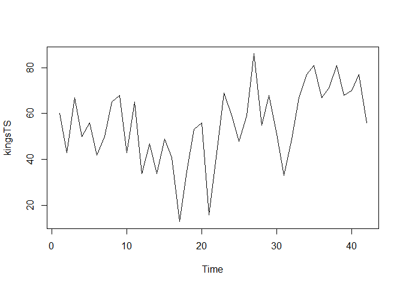

Birth plot can be explained best by an additive model since the seasonal variation is constant

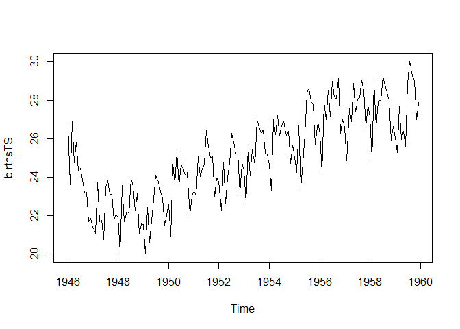

The Plot of Souvenior has seasonal fluctuations and hence can be best explained by a multiplicative model (the amplitude of seasonal variance is not constant)

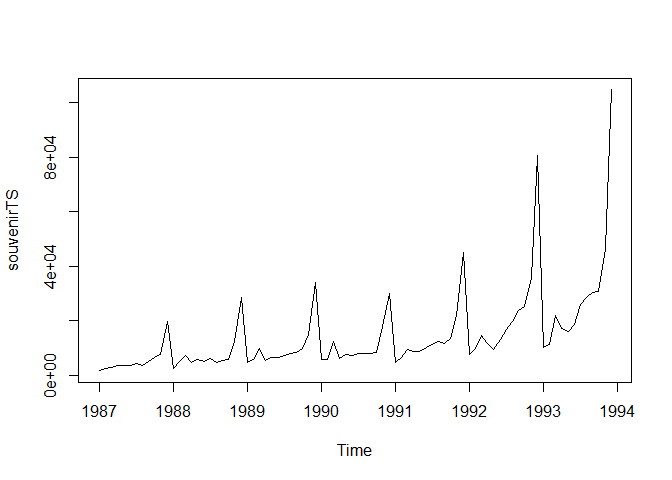

To convert a multiplicative model into a additive model take logarithms and the seasonality amplitude looks constant

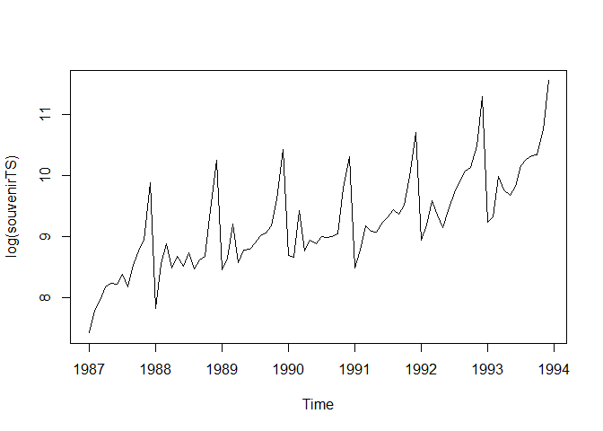

For a non seasonal data the trend can be explained by a simple moving average

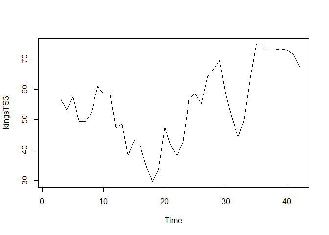

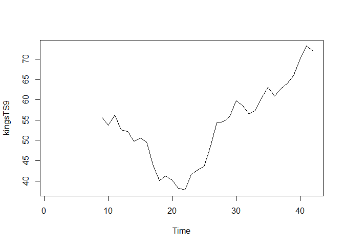

Decomposing : Means getting the trend,Seaonality and error

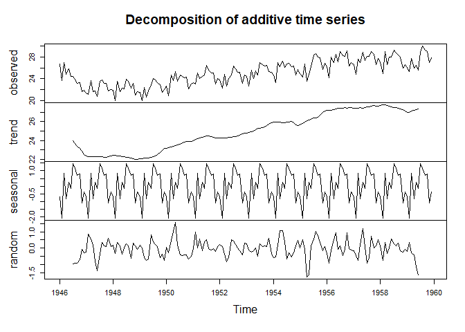

Decomposing a Multiplicative series- by subtracting the seasonality.Decompose is used to understand the trend without the effect of seasonality

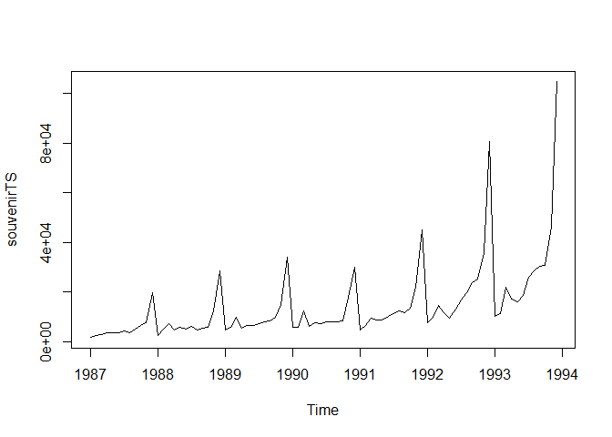

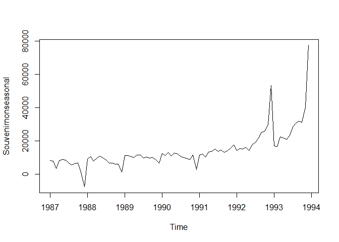

Simple Exponential smoothing : no trend and no seasonality

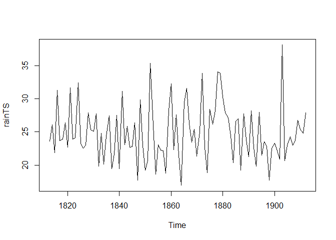

### SIMPLE EXPONENTIAL SMOOTHING

Forecasting the above using HoltWinters.Simple exponential smoothing can be used for the above

```
## Holt-Winters exponential smoothing without trend and without seasonal component.
##
## Call:
## HoltWinters(x = rainTS, beta = FALSE, gamma = FALSE, l.start = 23.56)
##
## Smoothing parameters:
##  alpha: 0.02412151
##  beta : FALSE
##  gamma: FALSE
##
## Coefficients:
##       [,1]
## a 24.67819
```

```
## Time Series:
## Start = 1814
## End = 1912
## Frequency = 1
##          xhat    level
## 1814 23.56000 23.56000
## 1815 23.62054 23.62054
## 1816 23.57808 23.57808
## 1817 23.76290 23.76290
## 1818 23.76017 23.76017
## 1819 23.76306 23.76306
## 1820 23.82691 23.82691
## 1821 23.79900 23.79900
## 1822 23.98935 23.98935
## 1823 23.98623 23.98623
```

[output cut: 89 more lines]

Plotting the forecast against the actual data

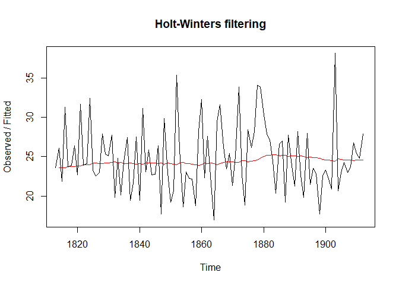

```
## [1] 1828.855
```

Making forecast for the next 8 periods.

Plotting the predicted forecast with a 80% and 95% confidence interval

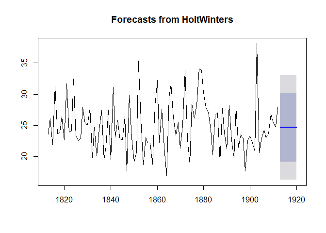

Getting the Correlogram of the residuals.If there is no corelation between the plotted acf’s then the model cannot be improved.

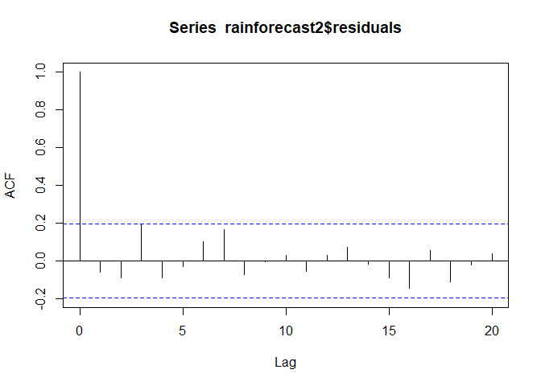

As per the above the plot Lag -3 is just touching the significane boundary.This can be further checked using the Ljung-Box Test

```
##
##  Box-Ljung test
##
## data:  rainforecast2$residuals
## X-squared = 17.401, df = 20, p-value = 0.6268
```

The p-value closer to 0 means there is a non-zero auto corealtion within the lags which is not the case in the above.Also the same can be checked by plotting the residuals to check for a zero mean and a constant variance

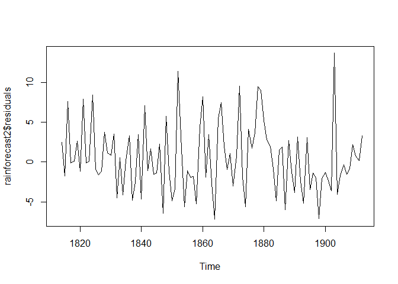

## HOLTS EXPONENTIAL SMOOTHING

If there is trend and no seasonality then the above is used.

```
## Holt-Winters exponential smoothing with trend and without seasonal component.
##
## Call:
## HoltWinters(x = skirtsTS, gamma = FALSE)
##
## Smoothing parameters:
##  alpha: 0.8383481
##  beta : 1
##  gamma: FALSE
##
## Coefficients:
##         [,1]
## a 529.308585
## b   5.690464
```

Plotting the forecast

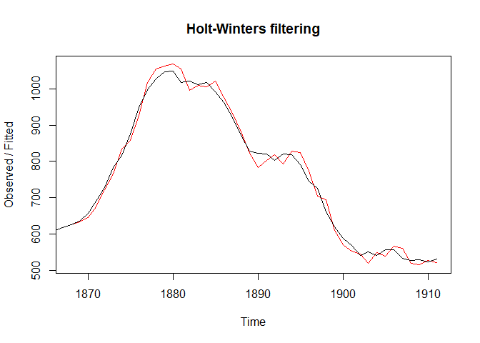

Making Forecast

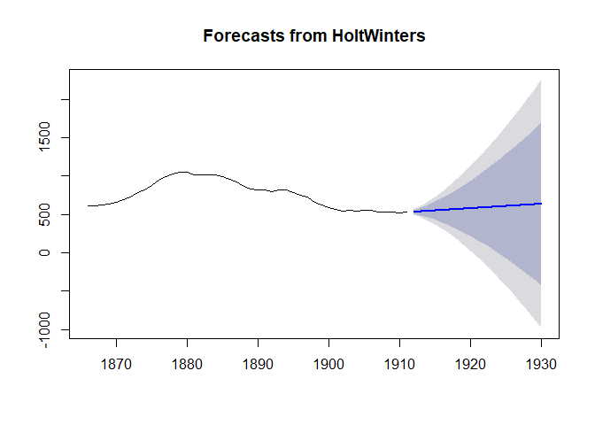

Testing the Possibility of betterment of the chosen method using ACF/Box-Lfung test and Plotting the residuals

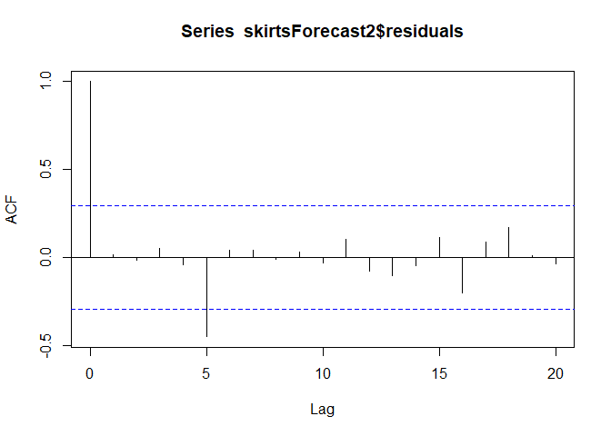

```
##
##  Box-Ljung test
##
## data:  skirtsForecast2$residuals
## X-squared = 19.731, df = 20, p-value = 0.4749
```

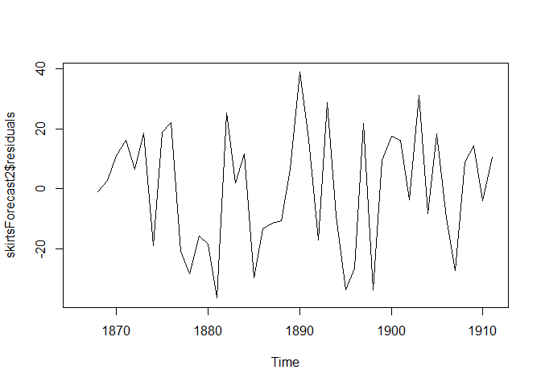

## HOLT WINTERS EXPONENTIAL SMOOTHING

The parameters alpha, beta and gamma all have values between 0 and 1, and values that are close to 0 mean that relatively little weight is placed on the most recent observations when making forecasts of future values.

The Souvenir data looked like a multiplicative model beacuse of the seasonality rise.However the same can be converted to an additive model by taking Logarithms.

```
## Holt-Winters exponential smoothing with trend and additive seasonal component.
##
## Call:
## HoltWinters(x = souvenirlog)
##
## Smoothing parameters:
##  alpha: 0.413418
##  beta : 0
##  gamma: 0.9561275
##
## Coefficients:
##            [,1]
## a   10.37661961
## b    0.02996319
## s1  -0.80952063
## s2  -0.60576477
## s3   0.01103238
## s4  -0.24160551
## s5  -0.35933517
## s6  -0.18076683
## s7   0.07788605
## s8   0.10147055
## s9   0.09649353
## s10  0.05197826
## s11  0.41793637
## s12  1.18088423
```

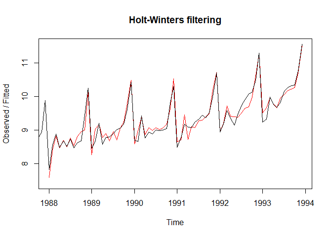

Forecasting for the next 48 months

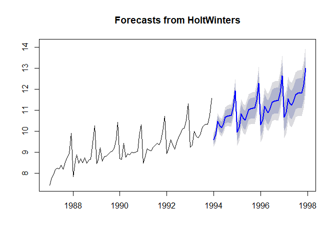

Checking the residual plot and the box method and ACF

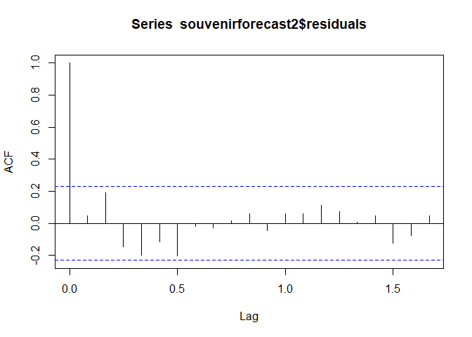

```
##
##  Box-Ljung test
##
## data:  souvenirforecast2$residuals
## X-squared = 17.53, df = 20, p-value = 0.6183
```

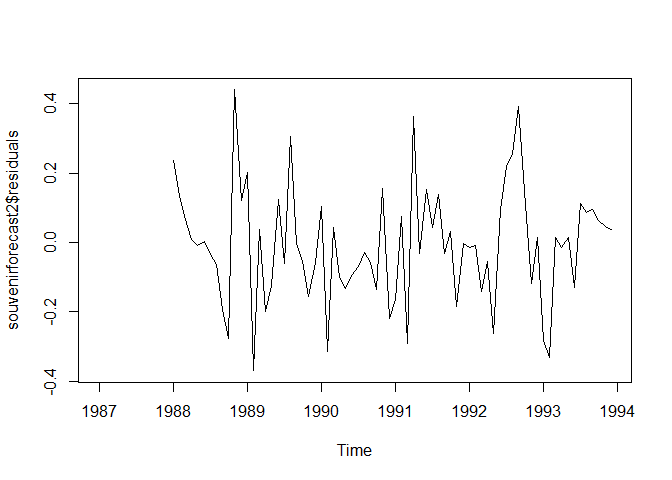

Based on the above we can conclude that the model is adequate in predicting the forecast.

## ARIMA model

In cases where the residual plot does not have a zero mean and a constant variance ARIMA models are helpful.

Using the Skirt data

Differentiating the same to arrive at a stationary TS

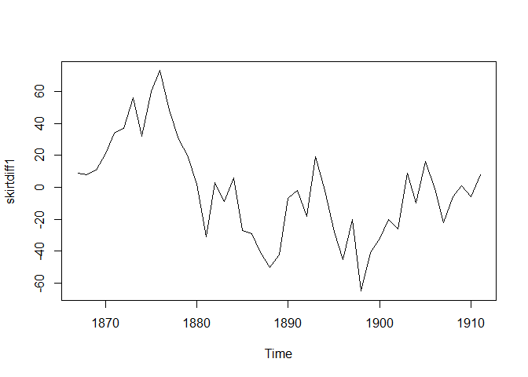

Differentiating once again since the above does not look stationary

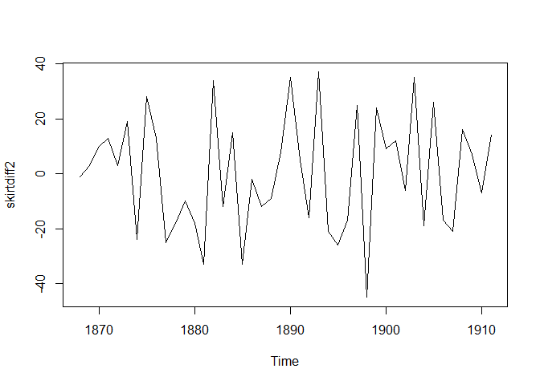

The above looks stationary hence we can proceed with the ARIMA(p,d,q) model.The order of differencing d for this case is 2.

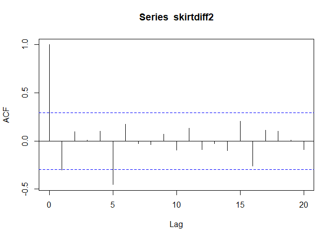

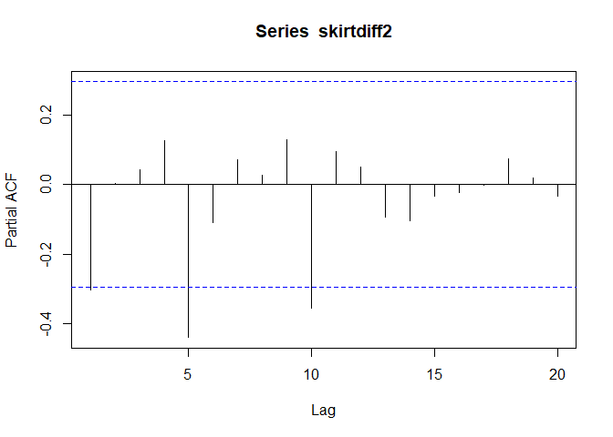

Both the ACF and PACF do not abruptly tail off and hence we can go for the ARIMA model(2,2,2).Also we can use the auto.ARIMA () to find the appropriate model

Another example

[output not shown]

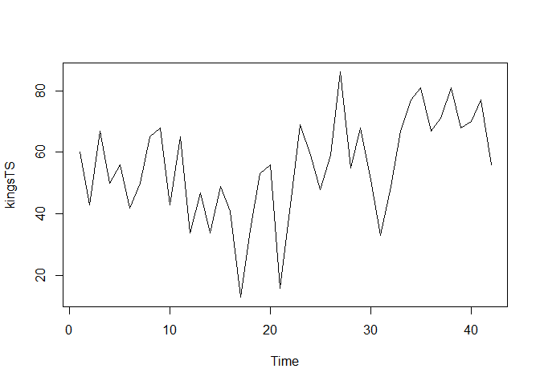

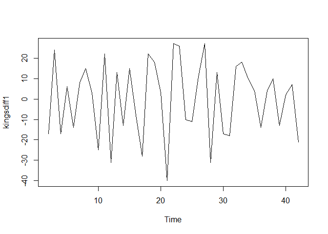

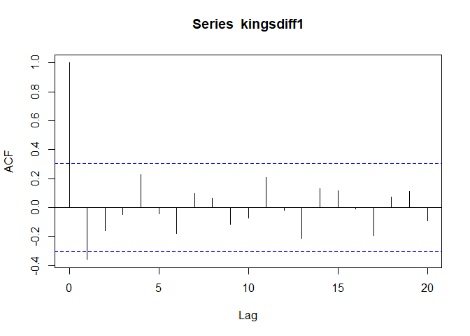

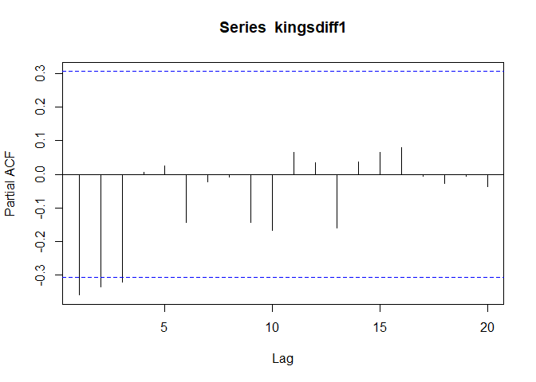

```
## Series: kingsTS
## ARIMA(0,1,1)
##
## Coefficients:
##           ma1
##       -0.7218
## s.e.   0.1208
##
## sigma^2 estimated as 236.2:  log likelihood=-170.06
## AIC=344.13   AICc=344.44   BIC=347.56
```

Getting the ARIMA values and forecast

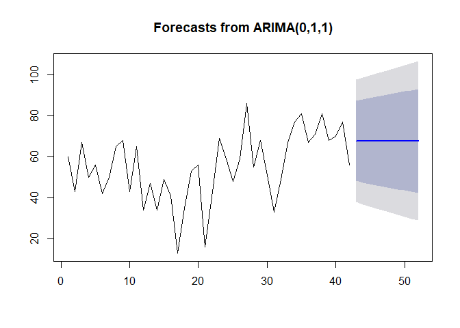

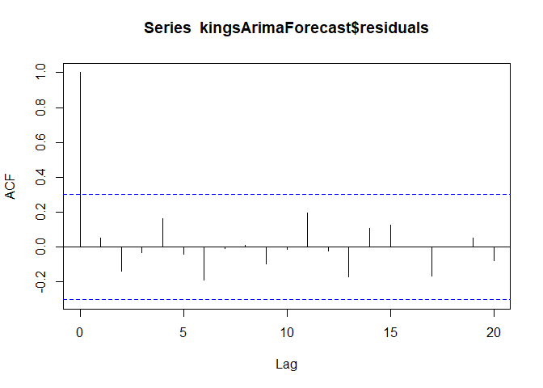